# EVIDENCIA 2 MD A01641442

Juan Pablo López Alvarado

2023-03-14

## R Markdown

```r
library (tidyverse)
```

```r
library(dplyr)
library(ggplot2)
library(readxl)
```

```r
#Lenyendo archivos de Excel teams, stadiums, players, managers, matches, goals y se convierten en dataframe teams, stadiums, players, managers, matches, goals

teams <- read_excel("UEFA Data SP.xlsx", sheet = "teams")
stadiums <- read_excel("UEFA Data SP.xlsx", sheet = "stadiums")
players <- read_excel("UEFA Data SP.xlsx", sheet = "players")
managers <- read_excel("UEFA Data SP.xlsx", sheet = "managers")
matches <- read_excel("UEFA Data SP.xlsx", sheet = "matches")
goals <- read_excel("UEFA Data SP.xlsx", sheet = "goals")
```

```r
View(teams)
View(stadiums)
view(players)
view(matches)
view(goals)
```

#1.-¿Cuál es la capacidad promedio, mayor y menor de los estadios europeos?

```r
promediosestadios <- stadiums%>%
  summary(CAPACITY)
promediosestadios
```

```
##      NAME               CITY             COUNTRY             CAPACITY
##  Length:86          Length:86          Length:86          Min.   : 4735
##  Class :character   Class :character   Class :character   1st Qu.:29834
##  Mode  :character   Mode  :character   Mode  :character   Median :43758
##                                                           Mean   :45295
##                                                           3rd Qu.:60800
##                                                           Max.   :99354
```

#al aplicar la función summary, es que podemos encontrar el promedio, mayor y menor de los estadios europeos, siendo estos 4,735 el minimo, 45,295 el promedio y 99,354 el maximo.

2.-¿Cuál es el top ten de los estadios europeos con capacidad superior al promedio (obtenido en la pregunta anterior) ?.Despliega Nombre, País y capacidad

```r
estadioscapacidad <- stadiums%>%
  select(NAME, CAPACITY, COUNTRY)%>%
  arrange(desc(CAPACITY))%>%
  head(10)
estadioscapacidad
```

```
## # A tibble: 10 × 3
##    NAME              CAPACITY COUNTRY
##    <chr>                <dbl> <chr>
##  1 Spotify Camp Nou     99354 Spain
##  2 Wembley Stadium      90000 England
##  3 Signal Iduna Park    81365 Germany
##  4 Stade de France      81338 France
##  5 Santiago Bernabéu    81044 Spain
##  6 Luzhniki             80840 Russia
##  7 Giuseppe Meazza      75923 Italy
##  8 Allianz Arena        75024 Germany
##  9 Millennium           74500 Wales
## 10 Old Trafford         74140 England
```

#En este segundo ejercicio, se pueden ver los 10 estadios con mayor capacidad dentro de la base de datos. Al volver a el primer ejercicio, donde el promedio era de 45,295, comprobamos que los 10 estadios que estan aquí, estan por encima del promedio. Esto se pudo hacer con la función select (para mostrar solo nombre y capacidad), arrange(desc(para mostrar los mas altos)) y finalmente head, para solo mostrar los primeros 10.

3.-¿Cuáles son los 10 equipos con más jugadores de la liga desde 2016 a 2022 y cuántos jugadores tiene cada equipo?. Elimina a los equipos con NA’s.

```r
equiposjugadores <- players %>%
  select(PLAYER_ID, TEAM)%>%
  group_by(TEAM)%>%
  filter(!is.na(TEAM))%>%
  summarise(num_jugadores=n())%>%
  arrange(desc(num_jugadores))%>%
  head(10)
equiposjugadores
```

```
## # A tibble: 10 × 2
##    TEAM               num_jugadores
##    <chr>                      <int>
##  1 Borussia Dortmund             48
##  2 Liverpool FC                  46
##  3 Manchester United             44
##  4 Olympiakos Piraeus            42
##  5 Slavia Praha                  39
##  6 Bayern München                38
##  7 Dinamo Kiev                   38
##  8 Ferencvárosi TC               37
##  9 APOEL Nikosia                 35
## 10 FK Krasnodar                  35
```

#En este tercer ejercicio, mediante el uso de las herramientas select, group_by, filter, summarise, arrange y head, se logro obtener los 10 equipos que mas jugadores han tenido en la competición. Así como lograr acomodarlos de manera descendente. Obtuvimos que el equipo Borussia Dortmund, de alemania, es el equipo que mas jugadores utilizo, con 48.

4.-¿Cuáles son los 10 estadios que recibieron mayor audiencia durante las ligas?. Despliega el estadio, la audiencia, equipo local y visitante.

```r
asistenciaestadios <- matches%>%
  select(STADIUM, ATTENDANCE, HOME_TEAM, AWAY_TEAM)%>%
  arrange(desc(ATTENDANCE))%>%
  head(10)

asistenciaestadios
```

```
## # A tibble: 10 × 4
##    STADIUM          ATTENDANCE HOME_TEAM    AWAY_TEAM
##    <chr>                 <dbl> <chr>        <chr>
##  1 Spotify Camp Nou      98299 FC Barcelona Liverpool FC
##  2 Spotify Camp Nou      97183 FC Barcelona Chelsea FC
##  3 Spotify Camp Nou      96708 FC Barcelona Manchester United
##  4 Spotify Camp Nou      96290 FC Barcelona Manchester City
##  5 Spotify Camp Nou      96290 FC Barcelona Paris Saint-Germain
##  6 Spotify Camp Nou      96290 FC Barcelona Juventus
##  7 Spotify Camp Nou      92346 FC Barcelona Olympique Lyon
##  8 Spotify Camp Nou      90106 FC Barcelona AS Roma
##  9 Spotify Camp Nou      90071 FC Barcelona Borussia Dortmund
## 10 Spotify Camp Nou      86290 FC Barcelona Inter
```

#En este cuarto inciso, obvtuve que los 10 partidos con mayor asistencia le pertenecen al estadio Spotify Camp nou, esto tiene mucho sentido debido a que en el ejercicio 2 de esta evidencia, se pudo ver que este es el estadio con mayor capacidad. Esto se pudo hacer mediante las funciones select, arrange, y head.

#VISUALIZACIÓN 1 - DISPERSIÓN.

```r
g1 <- matches%>%
  left_join(stadiums, by= c("STADIUM" = "NAME"))
g1
```

```
## # A tibble: 767 × 13
##    MATCH_ID SEASON    DATE_TIME      HOME_TEAM AWAY_TEAM STADIUM HOME_TEAM_SCORE
##    <chr>    <chr>     <chr>          <chr>     <chr>     <chr>             <dbl>
##  1 mt1      2021-2022 15-SEP-21 08.… Manchest… RB Leipz… Etihad…               6
##  2 mt2      2021-2022 15-SEP-21 08.… Club Bru… Paris Sa… Jan Br…               1
##  3 mt3      2021-2022 28-SEP-21 08.… Paris Sa… Manchest… Parc d…               2
##  4 mt4      2021-2022 28-SEP-21 08.… RB Leipz… Club Bru… Red Bu…               1
##  5 mt4      2021-2022 28-SEP-21 08.… RB Leipz… Club Bru… Red Bu…               1
##  6 mt5      2021-2022 19-OCT-21 05.… Club Bru… Manchest… Jan Br…               1
##  7 mt6      2021-2022 19-OCT-21 08.… Paris Sa… RB Leipz… Parc d…               3
##  8 mt7      2021-2022 03-NOV-21 08.… RB Leipz… Paris Sa… Red Bu…               2
##  9 mt7      2021-2022 03-NOV-21 08.… RB Leipz… Paris Sa… Red Bu…               2
## 10 mt8      2021-2022 03-NOV-21 08.… Manchest… Club Bru… Etihad…               4
## # … with 757 more rows, and 6 more variables: AWAY_TEAM_SCORE <dbl>,
## #   PENALTY_SHOOT_OUT <dbl>, ATTENDANCE <dbl>, CITY <chr>, COUNTRY <chr>,
## #   CAPACITY <dbl>
```

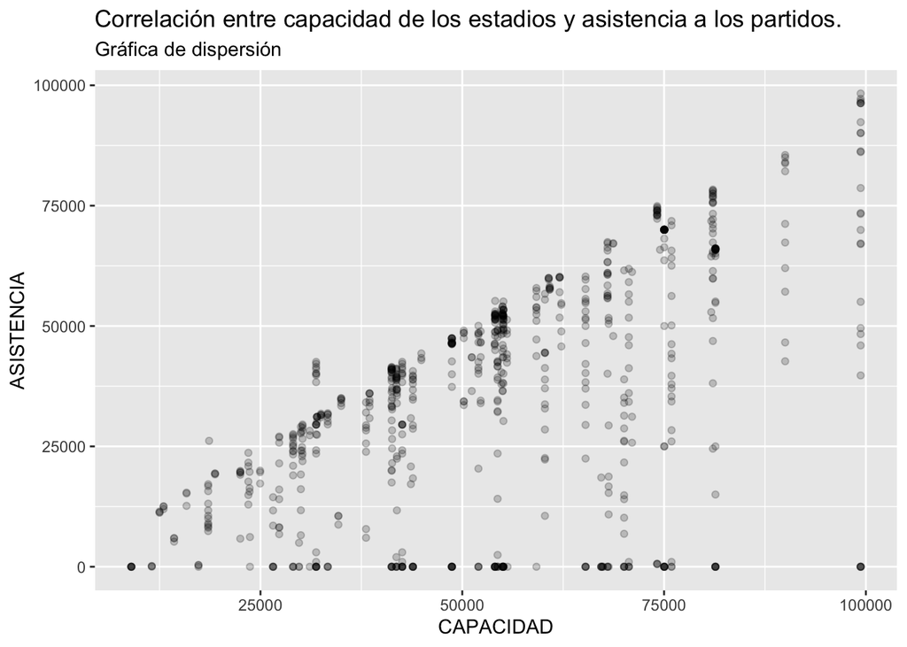

```r
ggplot(data = g1,
       mapping = aes(x = CAPACITY, y = ATTENDANCE)) +
  geom_point(alpha =0.2)+
  labs(title= "Correlación entre capacidad de los estadios y asistencia a los partidos. ",
       subtitle = "Gráfica de dispersión",
       x= "CAPACIDAD",
       y= "ASISTENCIA")
```

#VISUALIZACIÓN 2 BARRAS

```r
partidosanfield <- matches %>%
  filter(STADIUM =="Anfield")
partidosanfield
```

```
## # A tibble: 26 × 10
##    MATCH_ID SEASON    DATE_TIME      HOME_TEAM AWAY_TEAM STADIUM HOME_TEAM_SCORE
##    <chr>    <chr>     <chr>          <chr>     <chr>     <chr>             <dbl>
##  1 mt14     2021-2022 15-SEP-21 08.… Liverpoo… AC Milan  Anfield               3
##  2 mt20     2021-2022 03-NOV-21 08.… Liverpoo… Atlético… Anfield               2
##  3 mt21     2021-2022 24-NOV-21 08.… Liverpoo… FC Porto  Anfield               2
##  4 mt106    2021-2022 08-MAR-22 08.… Liverpoo… Inter     Anfield               0
##  5 mt120    2021-2022 13-APR-22 08.… Liverpoo… SL Benfi… Anfield               3
##  6 mt122    2021-2022 27-APR-22 08.… Liverpoo… Villarre… Anfield               2
##  7 mt165    2020-2021 27-OCT-20 08.… Liverpoo… FC Midtj… Anfield               2
##  8 mt169    2020-2021 25-NOV-20 08.… Liverpoo… Atalanta  Anfield               0
##  9 mt171    2020-2021 01-DEC-20 08.… Liverpoo… AFC Ajax  Anfield               1
## 10 mt245    2020-2021 14-APR-21 08.… Liverpoo… Real Mad… Anfield               0
## # … with 16 more rows, and 3 more variables: AWAY_TEAM_SCORE <dbl>,
## #   PENALTY_SHOOT_OUT <dbl>, ATTENDANCE <dbl>
```

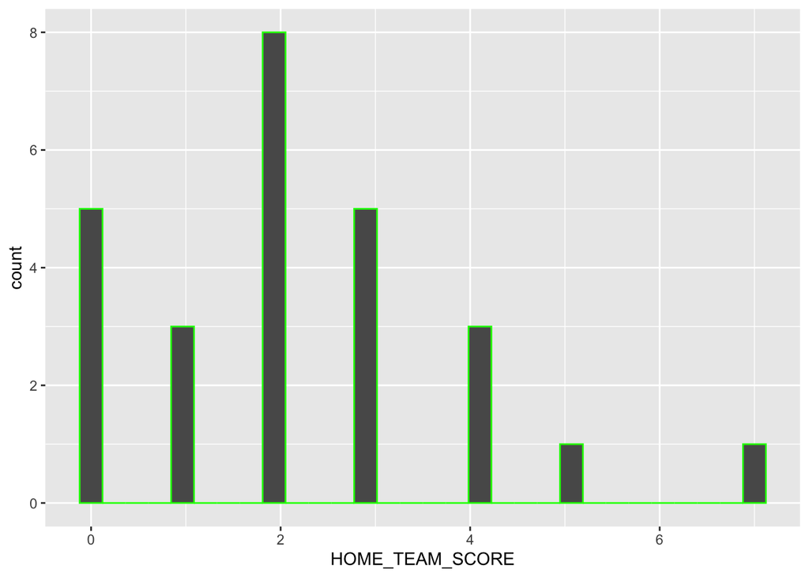

```r
ggplot(data = partidosanfield, mapping = aes(x = HOME_TEAM_SCORE)) +
  geom_histogram()+ geom_histogram(color = "green")
```

```r
  labs(title= "GOLES LIVERPOOL LOCAL",
       subtitle = "Histograma",
       x="Goles liverpool",
       y="frecuencia.")
```

```
## $x
## [1] "Goles liverpool"
##
## $y
## [1] "frecuencia."
##
## $title
## [1] "GOLES LIVERPOOL LOCAL"
##
## $subtitle
## [1] "Histograma"
##
## attr(,"class")
## [1] "labels"
```

#EN ESTA SEGUNDA VISUALIZACIÓN PODEMOS VER LOS GOLS QUE ANOTO EL EQUIPO LIVERPOOL EN SUS PARTIDOS DE LOCAL, A TRAVES DE TODAS LAS TEMPORADAS. ESTO NOS PERMITE VER EL RANGO DE GOLES QUE ANOTA, Y CUALES SON LA CANTIDAD DE GOLES QUE MAS ANOTA CUANDO ES LOCAL (SIENDO ESTE VALOR 2)

#VISUALIZACIÓN 3 HISTOGRAMAS.

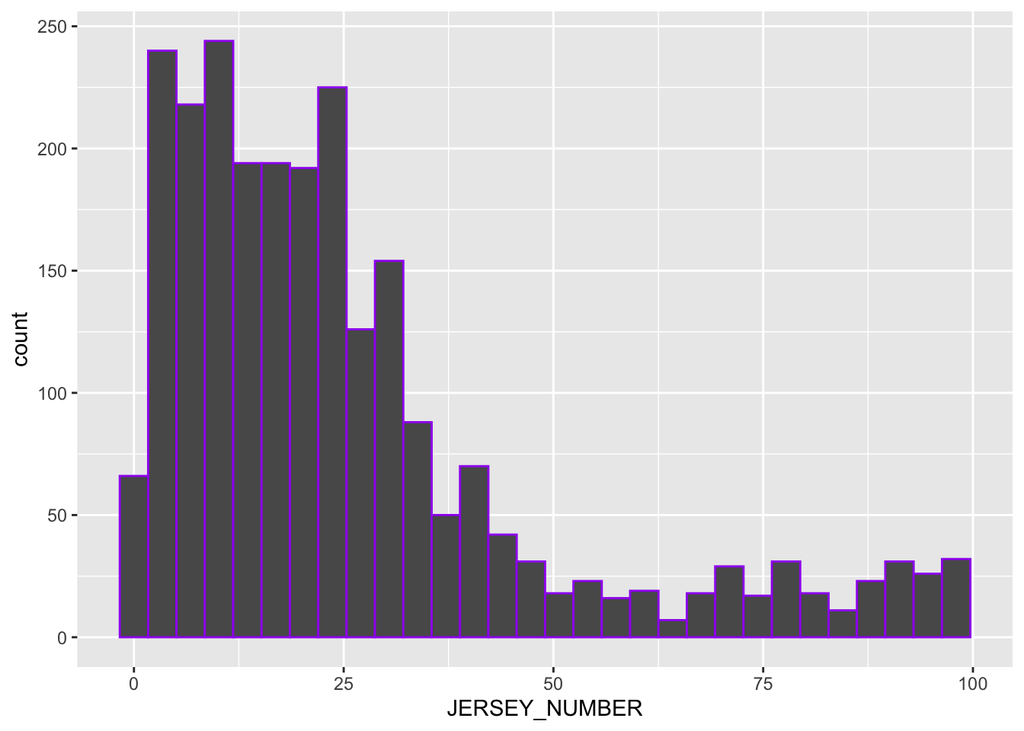

```r
g3 <- players
  ggplot(data = g3, mapping = aes(x = JERSEY_NUMBER)) + geom_histogram(color = "purple")
```

#EN ESTA TERCERA VISUALIZACIÓN, PODEMOS VER LA CANTIDAD DE VECES QUE SE REPITE EL NUMERO EN DORSAL DE CADA JUGADOR, AL ANALIZARLA, NOS DAMOS CUENTA QUE LOS NUMERO QUE MAS SE REPITEN VAN DESDE EL 1-30, Y DESPUES SE VE UNA REDUCCIÓN CONSIDERABLE, DANDONOS A ENTENDER QUE LOS NUMEROS POR ENCIMA DE 40, NO SON DE MUCHO AGRADO PARA LOS JUGADORES. #VISUALIZACIÓN 4 - FACETS

```r
estadiositalia <- matches %>%
  left_join(stadiums, by= c("STADIUM" = "NAME"))%>%
  filter(COUNTRY == "Italy")
```

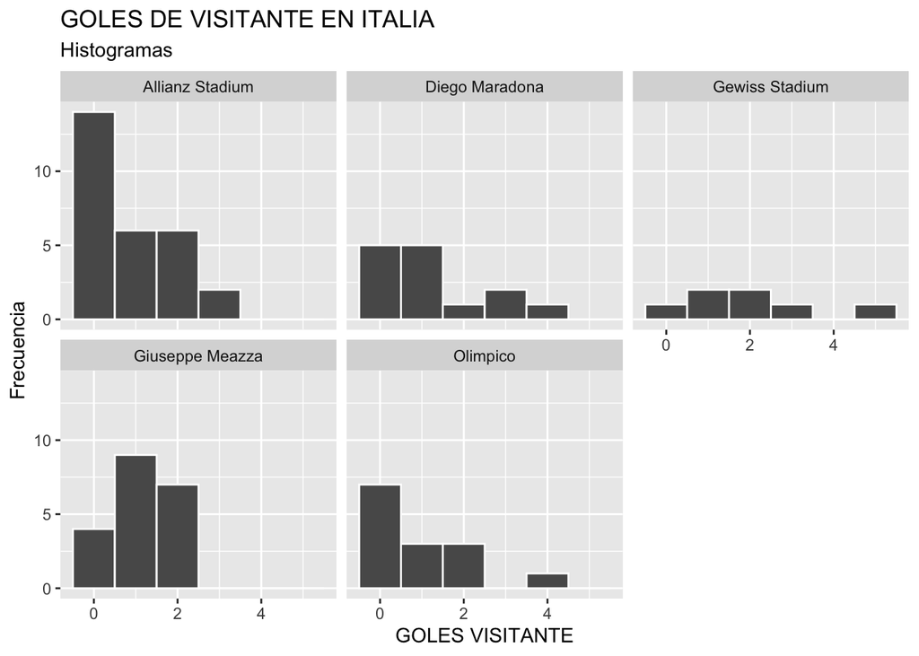

```r
ggplot(data = estadiositalia, mapping = aes(x = AWAY_TEAM_SCORE)) +
  geom_histogram(binwidth = 1, color = "white") +
  facet_wrap(~ STADIUM, nrow = 2)+
  labs(title="GOLES DE VISITANTE EN ITALIA",
       subtitle = "Histogramas",
       x="GOLES VISITANTE",
       y="Frecuencia")
```

#EN ESTA CUARTA VISUALIZACIÓN, PODEMOS VER FACETS, DONDE VEMOS LOS DIFERENTES ESTADIOS EN ITALIA, ASÍ COMO LA CANTIDAD DE GOLES QUE PUDO METER EL EQUIPO VISITANTE EN CADA UNO DE ELLOS.

```r
estadioscapacidad
```

```
## # A tibble: 10 × 3
##    NAME              CAPACITY COUNTRY
##    <chr>                <dbl> <chr>
##  1 Spotify Camp Nou     99354 Spain
##  2 Wembley Stadium      90000 England
##  3 Signal Iduna Park    81365 Germany
##  4 Stade de France      81338 France
##  5 Santiago Bernabéu    81044 Spain
##  6 Luzhniki             80840 Russia
##  7 Giuseppe Meazza      75923 Italy
##  8 Allianz Arena        75024 Germany
##  9 Millennium           74500 Wales
## 10 Old Trafford         74140 England
```

```r
ej4 <- estadioscapacidad%>%
  group_by(COUNTRY)
ej4
```

```
## # A tibble: 10 × 3
## # Groups:   COUNTRY [7]
##    NAME              CAPACITY COUNTRY
##    <chr>                <dbl> <chr>
##  1 Spotify Camp Nou     99354 Spain
##  2 Wembley Stadium      90000 England
##  3 Signal Iduna Park    81365 Germany
##  4 Stade de France      81338 France
##  5 Santiago Bernabéu    81044 Spain
##  6 Luzhniki             80840 Russia
##  7 Giuseppe Meazza      75923 Italy
##  8 Allianz Arena        75024 Germany
##  9 Millennium           74500 Wales
## 10 Old Trafford         74140 England
```

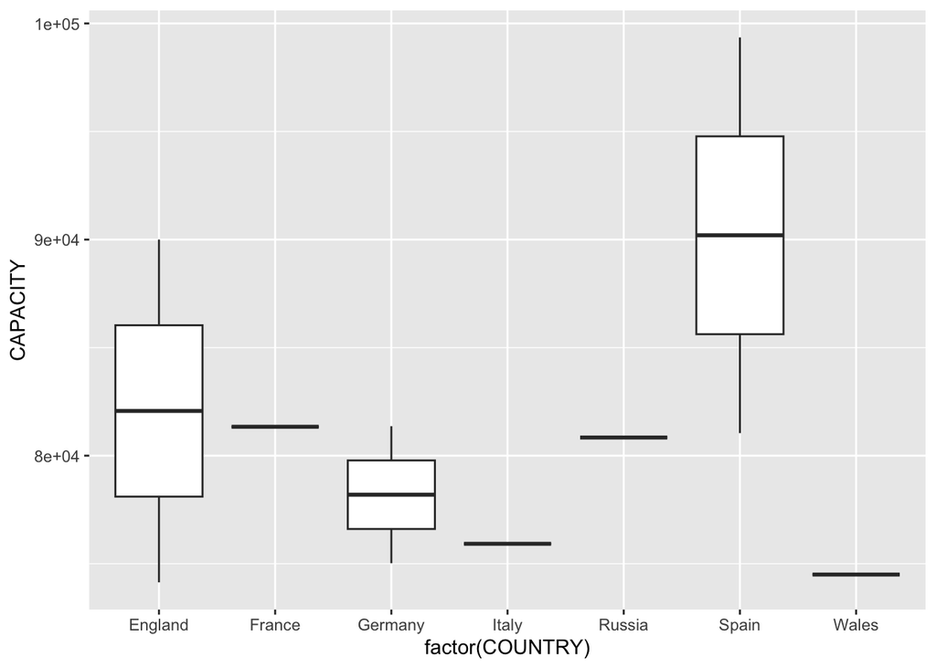

```r
ggplot(data = ej4, mapping = aes(x = factor(COUNTRY), y = CAPACITY)) + geom_boxplot()
```

#EN ESTA QUINTA VISUALIZACIÓN PODEMOS VER UNOS DIAGRAMAS DE CAJA, DONDE VOLVIENDO AL SEGUNDO EJERCICIO REALIZADO, Y AGRUPANDO POR PAIS, EN LOS ESTADIOS CON PAISES QUE SE REPITEN DEL TOP 10 CON MAS CAPACIDAD, PODEMOS VER UN DIAGRAMA DE CAJA.

Parte III Compromiso ético y ciudadano • Describe el valor de la integridad. • Agrega una reflexión personal de cómo puedes actuar con respeto y honestidad en los negocios y en el uso de datos cuando realices análisis de datos y estés en contacto con los datos de una empresa. • Agrega al menos tres referencias bibliográficas y cítalas en el punto anterior. Referencia adicional para esta sub sección: http://codigoeticaeintegridad.com/ #EL VALOR DE LA INTEGRIDAD. #La integridad es un valor fundamental en la sociedad, esta se basa en la honestidad, y la ética en todas las acciones y decisiones que tomamos en día a día. Implica actuar con responsabilidad y de acuerdo con lo que se considera correcto y justo, incluso en situaciones difíciles, la integridad es un pilar esencial para construir relaciones de confianza, tanto en el ámbito personal como profesional. Por otra parte, es un requisito indispensable para el éxito y el respeto en cualquier área de la vida. La falta de integridad puede generar consecuencias negativas tanto para uno mismo como para quienes lo rodean. #REFLEXIÓN PERSONAL. #Como reflexión personal, en el uso de datos y en los negocios, el actuar con respeto y honestidad significa el siempre ser honesto con los resultados que se tienen, o en otras palabras, jamas manipular una base de datos de una manera que se enseñen o muestren datos que verdaderamente “no” se encuentran ahí. Como analistas de datos, es nuestra responsabilidad ser honestos en todo momento, pues “manipular de mala manera” una base de datos, podria significar la desinformación total de una empresa, y malas tomas de decisiones. #REFERENCIAS “The Importance of Integrity in Business” por Entrepreneur de https://www.entrepreneur.com/article/293715 “Why Integrity is the Most Important Value to Have” por Forbes de https://www.forbes.com/sites/kathycaprino/2014/07/29/why-integrity-is-the-most-important-value-to-have/?sh=6c33c51269a5 “The Value of Integrity in Life and Business” por The Balance Small Business de https://www.thebalancesmb.com/the-value-of-integrity-in-life-and-business-4154177